# Spam Classifier Using Naive Bayes

### Quick Overview

The Naive Bayes Classifier is a fairly simple application of the Bayes Theorem. It works best for data where each feature is independent, which is why it is commonly used for applications such as text processing.

What I plan to do is to tokenize the sms text and use the Naive Bayes classifier to train a model that will determine whether future texts are spam or not.

```r
sms_data <- read.csv('./spam.csv', colClasses = c('factor', 'character'))
sms_data$X <- NULL
sms_data$X.1 <- NULL
sms_data$X.2 <- NULL
colnames(sms_data) <- c('Class', 'Text')
```

We ignore the last three columns there are an insignificant amount of entries in them.

Next, I want to visualize the amount of spam and ham emails that are in the dataset.

```r
library(ggplot2)
```

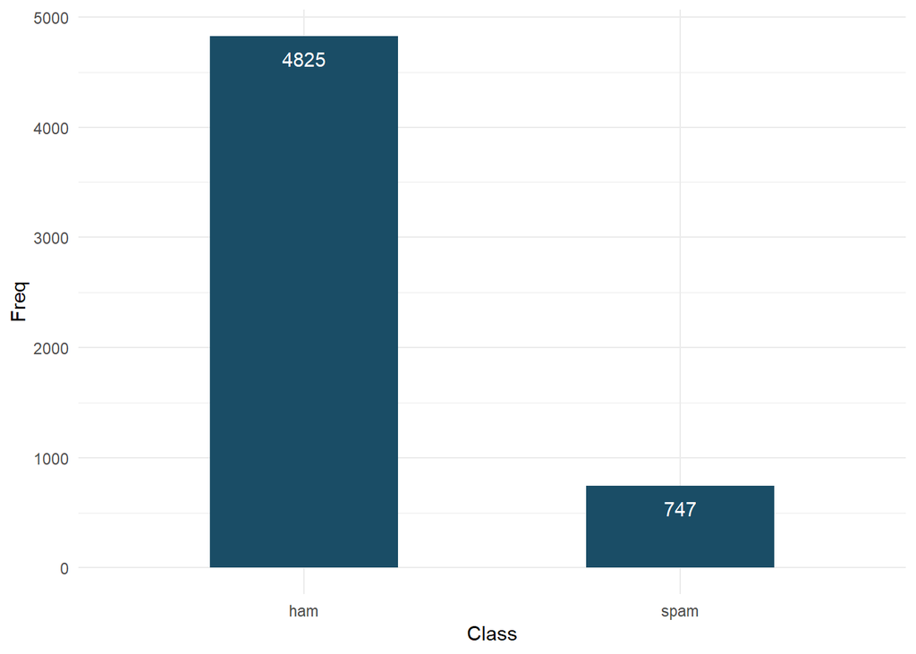

```r
class_table <- table(sms_data$Class)
class_table_df <- as.data.frame(class_table)
colnames(class_table_df) <- c('Class', 'Freq')
ggplot(class_table_df, aes(x = Class, y = Freq)) +
  geom_bar(stat = 'identity', width = 0.5, fill = rgb(0.1, 0.3, 0.4)) +
  geom_text(aes(label = Freq), color = 'white', vjust = 2) +
  theme_minimal()
```

What other meta-features of the text can we get before looking at each word individually?

I want to see the length of the text, as I have a feeling longer messages will be more likely to be spam.

```r
sms_length <- data.frame('class' = sms_data$Class, 'length' = nchar(sms_data$Text))
head(sms_length)
```

|  | class | length |
| --- | --- | --- |
| 1 | ham | 111 |
| 2 | ham | 29 |
| 3 | spam | 155 |
| 4 | ham | 49 |
| 5 | ham | 61 |
| 6 | spam | 148 |

Now I’ll plot it in a histogram and see what sort of structure we get.

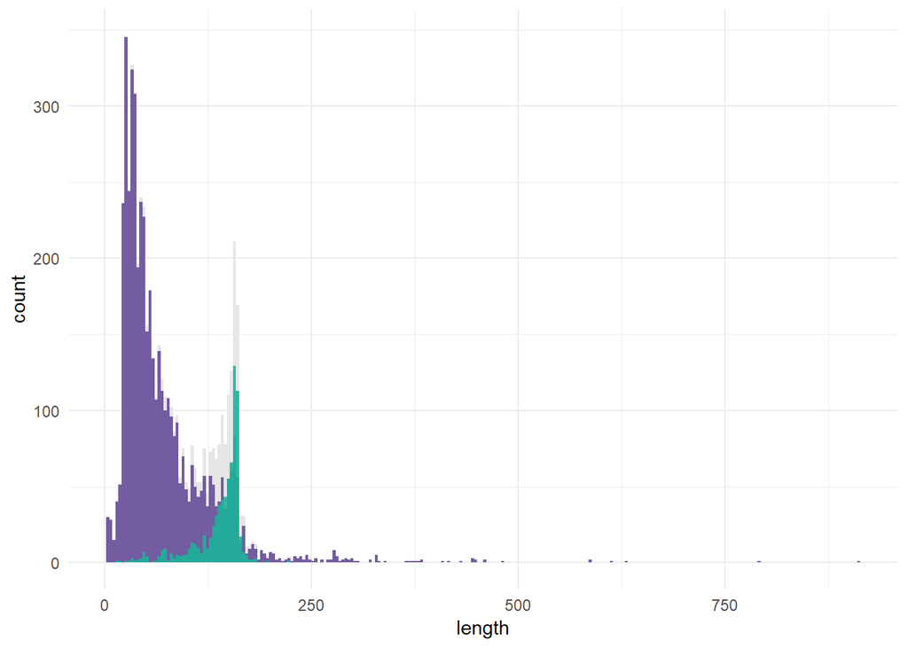

```r
sms_length_spam <- sms_length[sms_length$class == 'spam',]
sms_length_ham <- sms_length[sms_length$class == 'ham',]
ggplot(data = sms_length, aes(x = length)) +
  geom_histogram(bins = 250, fill = rgb(0.9, 0.9, 0.9)) +
  geom_histogram(data = sms_length_ham, bins = 250, fill = rgb(0.4, 0.3, 0.6), alpha = 0.9) +
  geom_histogram(data = sms_length_spam, bins = 250, fill = rgb(0.1, 0.7, 0.6), alpha = 0.9) +
  scale_fill_manual(name = 'classes', values = c(rgb(0.4, 0.3, 0.6), rgb(0.1, 0.7, 0.6)), labels = c('Ham', 'Spam')) +
  theme_minimal()
```

#### Tokenizing the Messages

Tokenizing strings is a common practice across computer languages. That is, to split a string into small string tokens using some delimiter character, and putting it into an array.

In order to prepare the data for the Naive Bayes Classifier, I have to separate each word into its own word-class pair.

Luckily, R provides several libraries to help with cleaning strings. The standard for this sort of classification is also to use a Document Term Matrix to store our string tokens, which will also store the frequency of each word.

```r
library(tm)
library(SnowballC)
```

```r
sms_docs <- Corpus(VectorSource(sms_data$Text))
inspect(sms_docs[1:3])
```

```
## <<SimpleCorpus>>
## Metadata:  corpus specific: 1, document level (indexed): 0
## Content:  documents: 3
##
## [1] Go until jurong point, crazy.. Available only in bugis n great world la e buffet... Cine there got amore wat...
## [2] Ok lar... Joking wif u oni...
## [3] Free entry in 2 a wkly comp to win FA Cup final tkts 21st May 2005. Text FA to 87121 to receive entry question(std txt rate)T&C's apply 08452810075over18's
```

TM also provide mapping functions which can intelligently remove elements such as numbers, punctuations, and so on.

```r
# Convert to lowercase so "Hi" and "hi" are considered the same
sms_docs_modified <- tm_map(sms_docs, tolower)
# Remove periods and commas
sms_docs_modified <- tm_map(sms_docs_modified, removePunctuation)
# Numbers are meaningless here by themselves
sms_docs_modified <- tm_map(sms_docs_modified, removeNumbers)
# Remove words specified by the stopword() function, including words like "and", "as", etc.
sms_docs_modified <- tm_map(sms_docs_modified, removeWords, stopwords())
# Remove excessive whitespace
sms_docs_modified <- tm_map(sms_docs_modified, stripWhitespace)

inspect(sms_docs_modified[1:3])
```

```
## <<SimpleCorpus>>
## Metadata:  corpus specific: 1, document level (indexed): 0
## Content:  documents: 3
##
## [1] go jurong point crazy available bugis n great world la e buffet cine got amore wat
## [2] ok lar joking wif u oni
## [3] free entry wkly comp win fa cup final tkts st may text fa receive entry questionstd txt ratetcs apply overs
```

Now I’ll store the documents into a Document Term Matrix.

```r
doc_matrix <- DocumentTermMatrix(sms_docs_modified)
str(doc_matrix)
```

```
## List of 6
##  $ i       : int [1:43958] 1 1 1 1 1 1 1 1 1 1 ...
##  $ j       : int [1:43958] 1 2 3 4 5 6 7 8 9 10 ...
##  $ v       : num [1:43958] 1 1 1 1 1 1 1 1 1 1 ...
##  $ nrow    : int 5572
##  $ ncol    : int 8203
##  $ dimnames:List of 2
##   ..$ Docs : chr [1:5572] "1" "2" "3" "4" ...
##   ..$ Terms: chr [1:8203] "amore" "available" "buffet" "bugis" ...
##  - attr(*, "class")= chr [1:2] "DocumentTermMatrix" "simple_triplet_matrix"
##  - attr(*, "weighting")= chr [1:2] "term frequency" "tf"
```

#### Subsetting the Data

Now I’m going to split the matricies into the training and test set. I’m going to use the same method I used in the Diabetes data set: using the sample method. Just like usual, I’ll split it into 70/30 for the training and test set respectively.

```r
nRows <- nrow(sms_data)
sampleIndexes <- sample(1:nRows, 0.7 * nRows, replace = FALSE)
sms_data_train <- sms_data[sampleIndexes, ]
sms_data_test <- sms_data[-sampleIndexes, ]
doc_matrix_train <- doc_matrix[sampleIndexes, ]
doc_matrix_test <- doc_matrix[-sampleIndexes, ]
sms_docs_train <- sms_docs_modified[sampleIndexes]
sms_docs_test <- sms_docs_modified[-sampleIndexes]
```

#### Cleaning up the Tokens

I want to remove rare words and focus on the ones that show up often in messages.

```r
# This function only returns the words that appear in n messages
frequent_words <- findFreqTerms(doc_matrix_train, 5)
head(frequent_words, n = 20)
```

```
##  [1] "available" "cine"      "crazy"     "got"       "great"
##  [6] "point"     "wat"       "world"     "lar"       "wif"
## [11] "apply"     "comp"      "cup"       "entry"     "final"
## [16] "free"      "may"       "receive"   "text"      "txt"
```

Now we can store this new set into a reduced matrix by using a dictionary filter.

```r
reduced_doc_matrix_train <- DocumentTermMatrix(sms_docs_train, list(dictionary = frequent_words))
reduced_doc_matrix_test <- DocumentTermMatrix(sms_docs_test, list(dictionary = frequent_words))
str(reduced_doc_matrix_train)
```

```
## List of 6
##  $ i       : int [1:22821] 1 1 1 1 1 1 1 2 2 2 ...
##  $ j       : int [1:22821] 1 2 3 4 5 6 7 8 9 10 ...
##  $ v       : num [1:22821] 1 1 1 1 1 1 1 1 1 1 ...
##  $ nrow    : int 3900
##  $ ncol    : int 1202
##  $ dimnames:List of 2
##   ..$ Docs : chr [1:3900] "1" "2" "3" "4" ...
##   ..$ Terms: chr [1:1202] "buy" "cause" "friendship" "lol" ...
##  - attr(*, "class")= chr [1:2] "DocumentTermMatrix" "simple_triplet_matrix"
##  - attr(*, "weighting")= chr [1:2] "term frequency" "tf"
```

Finally, the DocumentTermMatrix is incompatiable with the Naive Bayes Classifier we’ll be using, as it takes factors only. I’m going to borrow some code which can help turn our binary numbers into a factor vector.

```r
convert_to_factor <- function(x) {
  x = ifelse(x > 0, 1, 0)
  x = factor(x, levels = c(0, 1), labels=c("No", "Yes"))
  return(x)
}

reduced_doc_matrix_train = apply(reduced_doc_matrix_train, 2, convert_to_factor)
reduced_doc_matrix_test  = apply(reduced_doc_matrix_test, 2, convert_to_factor)
```

#### Performing the Classification

First I’ll import “e1071” which contains many common classification algorithms including Naive Bayes.

```r
library(e1071)
library(tidytext)
```

```r
classifier <- naiveBayes(reduced_doc_matrix_train, sms_data_train$Class)
prediction <- predict(classifier, reduced_doc_matrix_test)
table(prediction)
```

```
## prediction
##  ham spam
## 1469  203
```

Let’s look at the accuracy of our classifier:

```r
results_df <- data.frame('Expected' = sms_data_test$Class, 'Actual' = prediction)
head(results_df, n = 20)
```

|  | Expected | Actual |
| --- | --- | --- |
| 1 | ham | ham |
| 2 | ham | ham |
| 3 | ham | ham |
| 4 | ham | ham |
| 5 | ham | ham |
| 6 | ham | ham |
| 7 | ham | ham |
| 8 | ham | ham |
| 9 | ham | ham |
| 10 | ham | ham |

[output cut: 10 more lines]

Looking good so far. Let’s find the accuracy of our classifier.

```r
correct_results <- results_df[results_df$Expected == results_df$Actual,]
incorrect_results <- results_df[results_df$Expected != results_df$Actual,]
accuracy <- round(nrow(correct_results) / nrow(results_df) * 100, 2)
paste(c('Accuracy: ', accuracy, '%'), collapse = '')
```

```
## [1] "Accuracy: 97.79%"
```

```r
table(incorrect_results)
```

```
##         Actual
## Expected ham spam
##     ham    0    5
##     spam  32    0
```

It’s possible some *zero frequencies* are getting through into our classifier and hurting its accuracy. Luckily, the naiveBayes functions has laplace smoothing built in, so we can perhaps improve the results a bit.

```r
classifier_the_sequel <- naiveBayes(reduced_doc_matrix_train, sms_data_train$Class, laplace = 1)
prediction_ts <- predict(classifier_the_sequel, reduced_doc_matrix_test)
results_df_ts <- data.frame('Expected' = sms_data_test$Class, 'Actual' = prediction_ts)
correct_results_ts <- results_df_ts[results_df_ts$Expected == results_df_ts$Actual,]
incorrect_results_ts <- results_df_ts[results_df_ts$Expected != results_df_ts$Actual,]
accuracy_ts <- round(nrow(correct_results_ts) / nrow(results_df_ts) * 100, 2)
paste(c('Accuracy: ', accuracy_ts, '%'), collapse = '')
```

```
## [1] "Accuracy: 97.73%"
```

Well I said it was possible but I guess this didn’t change much.